## 1.3. Fuentes de datos externas oficiales (INE, EUROSTAT…)

Las fuentes de datos oficiales son un gran recurso para enriquecer la calidad de los datos utilizados dentro de nuestro análisis.

Supone una fuente de datos fiables, exhaustivos, tanto en temática como en ámbito geográfico, y habitualmente se pueden actualizar de forma recurrente.

Este tema se centra en la exploración de 3 fuentes de datos de 3 ámbitos:

- **Nacional**: Instituto Nacional de Estadística ([INE](https://www.ine.es/)).
- **Europeo**: Oficina estadística de la Comisión Europea ([EUROSTAT](https://ec.europa.eu/eurostat)).
- **Global**: Datos abiertos del Banco Mundial ([WORLD DATA BANK](https://data.worldbank.org/)).

##### Actividad guiada 1.1.

Con el objetivo de obtener datos relacionados con nuestra saga cinematográfica favorita, Star Wars, se pide buscar estadísticas en 2 sentidos:

- Analizar el volumen de población en cada región, por tramos de edad, con el objetivo de invertir más o menos presupuesto de publicidad.
- Conocer el volumen de facturación de la industria cinematográfica por año.

<piensa un minuto>La Clasificación Nacional de Actividades Económicas ([CNAE](https://www.ine.es/uc/IqQUWcoZ)) es utilizada por las oficinas estadísticas y está uniformizada por toda la Unión Europea. Permite identificar 630 actividades económicas distintas agrupadas de forma jerárquica en 2, 3 y 4 dígitos. Las “Actividades cinematográficas, de vídeo y de programas de televisión” tiene el epígrafe **“591”**. Puedes ver el listado completo en el siguiente [enlace](https://www.ine.es/daco/daco42/clasificaciones/cnae09/estructura_cnae2009.xls) del INE

### 1.3.1. Instituto Nacional de Estadística (INE)

El INE es un organismo del estado Español con un papel destacado en la actividad estadística pública. Realiza los censos demográficos, económicos, las cuentas nacionales, estadísticas demográficas y sociales, indicadores económicos y sociales, coordinación y mantenimiento de los directorios de empresas, formación del Censo Electoral,…

Además, regula las relaciones con las oficinas de estadística territoriales y con la Oficina Estadística de la Unión Europea (EUROSTAT).

El INE ha creado el espacio **Datos abiertos**, accesible tanto a través de la web del INE: www.ine.es/datosabiertos, como a través del portal [datos.gob.es](http://datos.gob.es/). Los conjuntos de datos y aplicaciones más relevantes son:

- Información estadística elaborada por el INE y publicada en [INEbase](https://www.ine.es/dyngs/INEbase/listaoperaciones.htm): Permite acceder a los resultados agregados de las estadísticas por temas.
- [Microdatos](https://www.ine.es/prodyser/microdatos.htm) anonimizados de encuestas: Permite acceder a los datos obtenidos de algunas encuestas a nivel de registros (microdatos) de forma anónima. En general consiste en ficheros de texto, con columnas en formato de ancho fijo. Su lectura requiere el uso de un diccionario, que especifica el significado de cada variable.
- [Callejero](https://www.ine.es/prodyser/callejero/) de censo electoral: Contiene el catálogo de calles, números de calle y códigos postales en España.
- [API JSON](https://www.ine.es/dyngs/DataLab/manual.html?cid=45): Especifica una API de consulta de los datos de INEbase y Tempus3.

#### INEBASE

Los datos de [INEbase](https://www.ine.es/dyngs/INEbase/listaoperaciones.htm) se pueden consumir directamente desde la web. El procedimiento es simple. Se navega por el árbol temático para seleccionar aquellos datos que puedan ser de nuestro interés.

Para nuestra actividad vamos a centrarnos en los apartados de “Demografía y población” y “Economía”.

##### Demografía y población

Tenemos 2 apartados de nuestro interés:

- Padrón. Población por municipios:
  - Estadística del Padrón continuo: (01/01/2020)
- Cifras de población y Censos demográficos
  - Cifras de población: (Datos provisionales 01/01/2020)

El **Padrón Municipal**, es un **registro** donde constan los vecinos del municipio. Su gestión está al cargo de los respectivos ayuntamientos. Se publican cada 1 de Enero e informan los totales de población hasta nivel inframunicipal de sección censal.

<sabías que>Sección censal es la unidad mínima de información estadística. Se utiliza parar organizar los procesos electorales. Agrupan entre 1.500 y 2.000 habitantes.</sabías que>

A su vez, las **Cifras de Población** son una operación estadística. Utiliza distintas encuestas para elaborar las cifras oficiales de población. Se publican los datos de forma semestral a nivel de provincia.

Para nuestra actividad, nos centramos en la [Estadística del Padrón continuo](https://www.ine.es/dyngs/INEbase/es/operacion.htm?c=Estadistica_C&cid=1254736177012&menu=ultiDatos&idp=1254734710990) > Resultados > Comunidades autónomas y provincias > [2.3 Población por edad (grupos quinquenales) y sexo](https://www.ine.es/jaxi/Tabla.htm?path=/t20/e245/p04/provi/l0/&file=0ccaa003.px&L=0)

[figure not shown]

<imagen1>Imagen: Padrón continuo (Fuente: [INE](https://www.ine.es) ). (www/01_ine.png){width=750px}

Se selecciona “Ambos sexos”, todas las Comunidades y Edades.

[figure not shown]

<imagen1>Imagen: Población por Comunidad y Edad (Fuente: [INE](https://www.ine.es) ). (www/02_ine.png){width=750px}

Posteriormente el formulario permite descargar los datos en distintos formatos (csv, Excel…), así como generar gráficos y mapas:

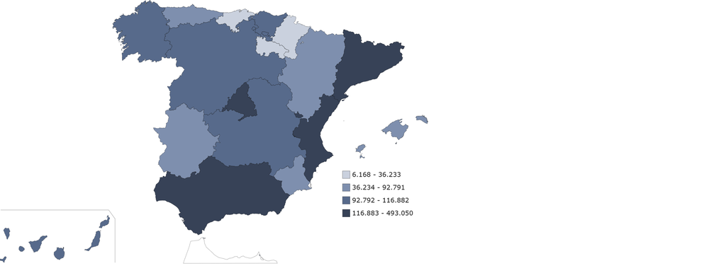

<imagen1>Imagen: Población de 10-14 años (Fuente: [INE](https://www.ine.es) ). (www/03_ine.png){width=750px}

En el siguiente punto se muestra como descargar los datos directamente desde Python mediante la API JSON del INE. Con este objetivo se obtiene la url de los datos:

- Botón de flecha de Descarga
- Json
- Se abre una ventana y copiamos la url: `https://servicios.ine.es/wstempus/js/es/DATOS_TABLA//t20/e245/p04/provi/l0/0ccaa003.px?tip=AMtv=sexo:ambossexos`

#### API JSON

Abre 2.9. Gestión de datos en Colab

La [API JSON del INE](https://www.ine.es/dyngs/DataLab/manual.html?cid=45) permite acceder, mediante peticiones URL, a toda la información disponible en [INEbase](https://www.ine.es/dyngs/INEbase/listaoperaciones.htm). Las consultas a la API, según la fuente, pueden ser de dos tipos:

- **Base de datos de difusión (Tempus3)**: Datos principales publicados de forma periódica.
- **Repositorio de ficheros PC-Axis**: Resto de datos.

Para comprender el funcionamiento de cada una veamos dos ejemplos:

##### API - Tempus3

Descargamos la “Serie original. Índice general, por sectores y por ramas de actividad” disponible en la URL: https://www.ine.es/jaxiT3/Tabla.htm?t=25891.

- Buscamos “cinematográficas” en la caja “Sectores y ramas de actividad”, botón `Enter`, Seleccionamos “59 Actividades cinematográficas, de vídeo y de programas de televisión, grabación de sonido y edición musical”.
- Seleccionamos “Índice”
- Seleccionamos todos los periodos

[figure not shown]

<imagen1>Imagen: Índice Actividades cinematográficas (Fuente: [INE](https://www.ine.es) ). (www/04_ine.png){width=750px}

- Consultar selección
- Botón Descargar (flecha superior derecha)
- Json

[figure not shown]

<imagen1>Imagen: Descarga Índice Actividades cinematográficas (Fuente: [INE](https://www.ine.es) ). (www/05_ine.png){width=750px}

- A continuación se abre una ventana con la siguiente url: `https://servicios.ine.es/wstempus/js/es/DATOS_TABLA/25891?tip=AM&tv=387:17588&tv=3:83`
- Para poder generar la petición desde Python en primer lugar, se cargan las librerías y se declara la variable con la url.

```python
from urllib.request import urlretrieve
from urllib.request import urlopen
import json
import pandas as pd
import numpy as np

urlTempus3 = "https://servicios.ine.es/wstempus/js/es/DATOS_TABLA/25891?tip=AM&tv=387:17588&tv=3:83"
```

- Se descarga el contenido de la URL y lo pasamos a formato json.

```python
result = json.load(urlopen(urlTempus3))
```

- Se transforma de json a pandas.
- Se ordena por el campo fecha.
- Se genera el índice de fecha (con frecuencia mensual).
- Se eliminan los valores faltantes.
- Se selecciona la serie a partir de enero de 2018 en adelante.

```python
df=pd.DataFrame(result[0]["Data"]).sort_values(by=["Fecha"])
#df.index = pd.to_datetime(np.array(df["Fecha"], dtype=np.datetime64)).to_period('D')
df.index = pd.to_datetime(np.array(df["Fecha"], dtype=np.datetime64)).to_period('M')
df = df[df['Valor'].notna()]
df = df['2018-01':]
```

- Se genera el plot para visualizar la serie.

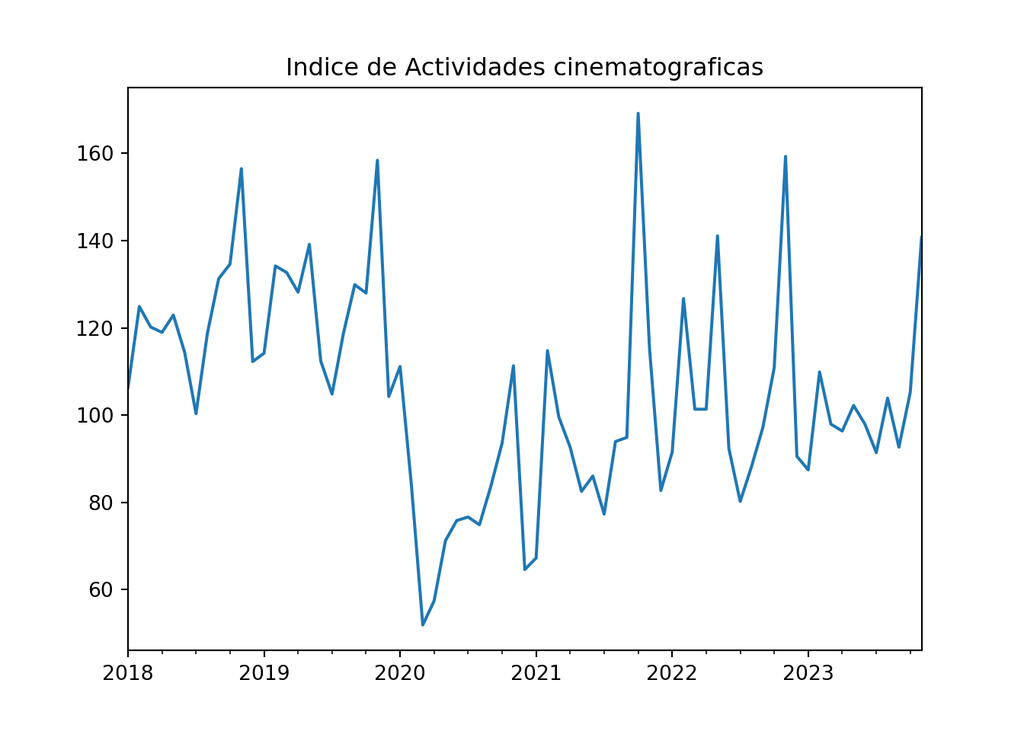

Índice de Actividades cinematográficas (fuente: elaboración propia con datos de INE) (plot1-1.png)

```python
df.Valor.plot.line(title='Indice de Actividades cinematograficas')
```

##### API - PCAXIS

- Recuperamos la url obtenida anteriormente.
- Se descargan los datos con urllib.

```python
urlPCAxis = "https://servicios.ine.es/wstempus/js/es/DATOS_TABLA//t20/e245/p04/provi/l0/0ccaa003.px?tip=AMtv=sexo:ambossexos"

result = json.load(urlopen(urlPCAxis))
```

```python
df = pd.DataFrame([x["Nombre"].split(",")+ [x["Data"][0]["Valor"]] for x in result if "Ambos sexos" in x["Nombre"] and "Total Nacional" in x["Nombre"]])
df.shape
```

```
## (0, 0)
```